# Cohomology

Fix a ring $R$.

#### Cochains and cohomology

- A *cochain complex* is a collection of free $R$-modules $C_n$ together with homomorphisms $\delta_n: C_n \to C_{n+1}$ such that $\delta_{n + 1} \circ \delta_n = 0$ for all $n$.
- We define the *cohomology* groups of a cochain as $H^*(n) = ker(\delta_n)/image(\delta_{n-1})$.
- We can define morphisms of cochain complexes and homotopies between such morphisms analogous to the case of chain complexes.

#### Dualizing

- Fix an $R$-module $M$. Then if $(C_*, \partial_*)$ is a chain complex of $R$-modules, $Hom(C_*, M)$ is a cochain complex with $\delta_* = (\partial_*)^*$.
- In particular we get singular, cellular and simplicial co-chain complexes of spaces.

#### Examples

1. $\mathbb{Z}\overset{0}\to \mathbb{Z}^2\overset{0}\to \mathbb{Z}$
2. $\mathbb{Z}\overset{0}\to \mathbb{Z} \overset{\times 2}\to\mathbb{Z}\overset{0}\to\mathbb{Z}$

We consider the second example with $M = \mathbb{Z}$ and with $M = \mathbb{Z}/2$.

#### Homology and cohomology for the examples

- First guess: Cohomology is dual to homology, i.e., $H^k(C_*, M) = Hom_R(H_k, M)$, where $H^k(C_*, M)$ is the cohomology of the cochain complex $Hom(C_*, M)$.
- In the first example, the co-chain complex is $\mathbb{Z} \to \mathbb{Z}^2\to \mathbb{Z}$, with maps $0$; satisfies the guess.
- In the second example (with $M= \mathbb{Z}$), $\mathbb{Z} \xrightarrow{0} \mathbb{Z} \xrightarrow{\times 2} \mathbb{Z} \xrightarrow{0} \mathbb{Z}\to 0$.

We compute cohomology:

- $H^0(C_*, \mathbb{Z}) = \mathbb{Z}$.
- $H^1(C_*, \mathbb{Z}) = 0 = Hom(H_1, \mathbb{Z})$.
- $H^2(C_*, \mathbb{Z}) = \mathbb{Z}/2 \neq Hom(H_2, \mathbb{Z})$

We compute cohomology:

- $H^0(C_*, \mathbb{Z}/2) = \mathbb{Z}/2$.
- $H^1(C_*, \mathbb{Z}) = \mathbb{Z}/2 = Hom(H_1(C_*, \mathbb{Z}/2), \mathbb{Z}/2)$.
- $H^2(C_*, \mathbb{Z}) = \mathbb{Z}/2 = Hom(H_2(C_*, \mathbb{Z}/2), \mathbb{Z}/2)$.

**Question:** Is cohomology determined by homology?

We answer this by:

- mapping to the dual and
- understanding the kernel
- Fix the module $M$.
- We have a homomorphism $H^k \to Hom(H_k, M) = Hom(Z_k/B_k, M)$; namely an element of $C^k = Hom(C_k, M)$ restricts to cycles and vanishes on boundaries if it is a cocycle.
- As $C_k$ is free, hence so are $Z_k$ and $B_k$, we can show that this is a surjection.
- This uses the split exact sequence $0 \to Z_k \to C_k \to B_{k-1}\to 0$.
- As we see from the example, this is not always injective, i.e., an isomorphism.

**Question:** What is the kernel of $H^k \to Hom(H_k, R)$?

Answer is *Universal coefficients theorem*.

We can define the cohomology of any module $H$ over $R$, namely,

- we take a free resolution $F_*$ of the $H$;
- this is unique up to chain homotopy;
- hence the cochain complex $Hom(F_*, M)$ is also unique up to (co-)chain homotopy;
- the cohomology of this is called the cohomology of $H$, denoted (in this context) by $Ext^k(H, M)$.

**Theorem:** There is a short exact sequence of $R$-modules $$0 \to Ext^1(H_{k-1}, M) \to H^k \to Hom(H_k, M)\to 0.$$

**Sketch of proof:**

- There is a short exact sequence of chain complexes $0\to Z_* \to C_* \to B_{* - 1} \to 0$, where the boundary maps are trivial in $Z_*$ and $B_*$.
- This induces a long exact sequence in cohomology: $\dots \to Z^{k -1} \to B^{k -1} \to H^{k} \to Z^{k} \to B^{k}\to \dots$.
- The kernel of $Z^k \to B^k$ is $Hom(H_k, M)$, i.e. we get $\dots \to Z^{k -1} \xrightarrow{\delta} B^{k -1} \to H^{k} \to Hom(H_k, M)\to 0$.
- Hence we have a short-exact sequence $0 \to coker(\delta)\to H^{k} \to Hom(H_k, M)\to 0$.

**Identification with Ext**

- We have a free resolution of $H_{k-1}$, namely $0\to B_{k-1} \to Z_{k-1}\to H_{k-1}$.
- From this, we see that $coker(\delta) = Ext^1(H_{k-1}, M)$.

```python
from IPython.display import Image
```

#### Rough whiteboard

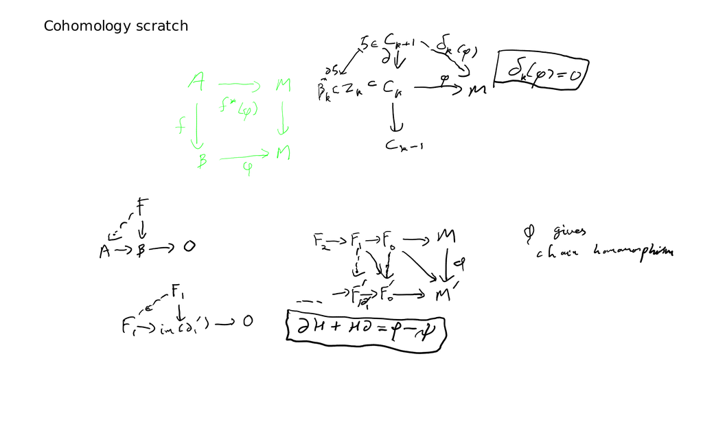

```python
Image("cohomology.png")
```